# Introduction to Spatial Analysis

Josh Havstad

2024-03-08

## Using Spatial Analysis to Analyze Shot Selection in Basketball

### Overview

This R Markdown file will cover spatial analysis. Spatial data sets can be found and applied in many disciplines, including earth sciences, cartography, biology, ecology, sociology, and more. Its applications can lead to impactful and meaningful changes in many public policies or social issues. Whether it is the position of players on a field or a court, the section and seat number of fans in the audience, travel routes for teams, or the location of TV viewers, spatial data can be found all across the sports world to benefit the team, the organization, and the fans. In this lesson, we will investigate how spatial analysis can be applied to basketball data. Analyzing shot selection of players based on location can help coaches create effective game plans to increase the success of their players and limit the success of opposing players.

#### What is spatial data?

Spatial data is data collected at locations defined by spatial coordinates. It is often referred to as “geospatial” data due to its primary use being with information on physical locations and events on earth. There are generally three main types of spatial data, including:

1. **Geostatistical** – This data is collected at fixed, geographically referenced locations. Geostatistical analysis deals with studying the spatial patterns, correlations, and variability of data from different locations or regions. Some techniques involved in this analysis include kriging, spatial autocorrelation analysis, and spatial interpolation. The main purposes or goals of working with geostatistical analysis include predicting future events, mapping, assessing risks, and monitoring environments.
2. **Areal** - This data is collected by predefined areas or zones (Ex: zip codes, counties, states). A few techniques which are used with areal data are cluster analysis, spatial ponit pattern analysis, hotspot analysis, or spatial data visualization. Areal analysis is meant to describe attributes or characteristics of entire areas. Some applications of this could be in demographic studies, public health studies, urban planning, market analysis, or socioeconomic research. This can assist with resource allocation or strategic planning in specific regions.
3. **Point pattern** - This data usually represents events as points in 2D space (Ex: (x,y) coordinates) and can represent occurrences of earthquakes, wildfires, disease cases, animal sightings, etc. Some main techniques associated with this data are spatial point pattern analysis, kernal density estimation, point pattern simulation, or cluster analysis. Point pattern data analysis can be used to explore patterns or trends in the locations of events.

In this example, we will be dealing with point pattern data, as the location of each basketball shot will be represented by (x,y) coordinates which represent different spots on the basketball court.

## The Data

We will be looking at data for each shot attempt in the 2022-2023 NBA season. This data can be found at the GitHub profile for *DomSamangy.*

Here is the link to the data: https://github.com/DomSamangy/NBA_Shots_04_23/blob/main/NBA_2023_Shots.csv.zip

```r
# import the data set and assign it a name
shots23 <- read.csv("~/Downloads/NBA_2023_Shots.csv")
# look at first 6 rows of the dataset
head(shots23)
```

```
##   SEASON_1 SEASON_2    TEAM_ID          TEAM_NAME PLAYER_ID        PLAYER_NAME
## 1     2023  2022-23 1610612764 Washington Wizards    203078       Bradley Beal
## 2     2023  2022-23 1610612764 Washington Wizards    204001 Kristaps Porzingis
## 3     2023  2022-23 1610612764 Washington Wizards   1628420       Monte Morris
## 4     2023  2022-23 1610612764 Washington Wizards    204001 Kristaps Porzingis
## 5     2023  2022-23 1610612764 Washington Wizards   1630166        Deni Avdija
## 6     2023  2022-23 1610612764 Washington Wizards    204001 Kristaps Porzingis
##   POSITION_GROUP POSITION  GAME_DATE  GAME_ID HOME_TEAM AWAY_TEAM  EVENT_TYPE
## 1              G       SG 10-19-2022 22200004       IND       WAS   Made Shot
## 2              C        C 10-19-2022 22200004       IND       WAS Missed Shot
## 3              G       PG 10-19-2022 22200004       IND       WAS   Made Shot
## 4              C        C 10-19-2022 22200004       IND       WAS   Made Shot
## 5              F       SF 10-19-2022 22200004       IND       WAS   Made Shot
## 6              C        C 10-19-2022 22200004       IND       WAS Missed Shot
##   SHOT_MADE                    ACTION_TYPE      SHOT_TYPE        BASIC_ZONE
```

[output cut: 20 more lines]

```r
# look at structure of data, variable types, and examples of variable values
str(shots23)
```

```
## 'data.frame':    217220 obs. of  26 variables:
##  $ SEASON_1      : int  2023 2023 2023 2023 2023 2023 2023 2023 2023 2023 ...
##  $ SEASON_2      : chr  "2022-23" "2022-23" "2022-23" "2022-23" ...
##  $ TEAM_ID       : int  1610612764 1610612764 1610612764 1610612764 1610612764 1610612764 1610612764 1610612764 1610612764 1610612764 ...
##  $ TEAM_NAME     : chr  "Washington Wizards" "Washington Wizards" "Washington Wizards" "Washington Wizards" ...
##  $ PLAYER_ID     : int  203078 204001 1628420 204001 1630166 204001 1628420 1628398 1628398 1628398 ...
##  $ PLAYER_NAME   : chr  "Bradley Beal" "Kristaps Porzingis" "Monte Morris" "Kristaps Porzingis" ...
##  $ POSITION_GROUP: chr  "G" "C" "G" "C" ...
##  $ POSITION      : chr  "SG" "C" "PG" "C" ...
##  $ GAME_DATE     : chr  "10-19-2022" "10-19-2022" "10-19-2022" "10-19-2022" ...
##  $ GAME_ID       : int  22200004 22200004 22200004 22200004 22200004 22200004 22200004 22200004 22200004 22200004 ...
##  $ HOME_TEAM     : chr  "IND" "IND" "IND" "IND" ...
##  $ AWAY_TEAM     : chr  "WAS" "WAS" "WAS" "WAS" ...
##  $ EVENT_TYPE    : chr  "Made Shot" "Missed Shot" "Made Shot" "Made Shot" ...
##  $ SHOT_MADE     : logi  TRUE FALSE TRUE TRUE TRUE FALSE ...
##  $ ACTION_TYPE   : chr  "Jump Shot" "Step Back Jump shot" "Running Finger Roll Layup Shot" "Cutting Dunk Shot" ...
##  $ SHOT_TYPE     : chr  "3PT Field Goal" "3PT Field Goal" "2PT Field Goal" "2PT Field Goal" ...
##  $ BASIC_ZONE    : chr  "Left Corner 3" "Above the Break 3" "Restricted Area" "Restricted Area" ...
##  $ ZONE_NAME     : chr  "Left Side" "Center" "Center" "Center" ...
##  $ ZONE_ABB      : chr  "L" "C" "C" "C" ...
##  $ ZONE_RANGE    : chr  "24+ ft." "24+ ft." "Less Than 8 ft." "Less Than 8 ft." ...
##  $ LOC_X         : num  23.4 -0.4 -1.3 -0.1 1.8 2 -2.2 19.7 -8.3 -2.3 ...
##  $ LOC_Y         : num  12.95 31.45 5.25 7.25 7.15 ...
##  $ SHOT_DISTANCE : int  24 26 1 2 2 26 2 24 25 3 ...
##  $ QUARTER       : int  1 1 1 1 1 1 1 1 1 1 ...
##  $ MINS_LEFT     : int  11 10 10 10 10 9 8 7 7 6 ...
##  $ SECS_LEFT     : int  20 52 39 31 5 25 25 58 29 46 ...
```

Taking a quick look at our data set, which has been named *shots23,* we can see that each observation (row) represents an individual shot attempt taken by a player during the 2022-2023 season, regardless of the outcome (make or miss). Some important variables that may be of interest include the player name, team names, player position, shot type, location of shot, and shot distance.

### Discussion

Working with a partner, what are some research questions or statistics you think a sports organization, coach, player, sports media outlet, etc. would be interested in answering or finding? For the purposes of this lesson, focus on ideas revolving around shot location.

### Exploratory Data Analysis

Exploratory data analysis and visualizing data should become a habit everytime we work with new data. In this section, we will quickly investigate some individual variables or relationships between variables that you may have discussed with your partner.

#### Shot Success by Shot Distance

Below, we can see the distribution of shot distances for both makes and misses. An NBA court is **94 feet in length by 50 feet in width**. The histograms below are cutoff at 47 feet, which may eliminate some shot attempts that occurred past half-court, but these are rare and usually occur at the end of quarters.

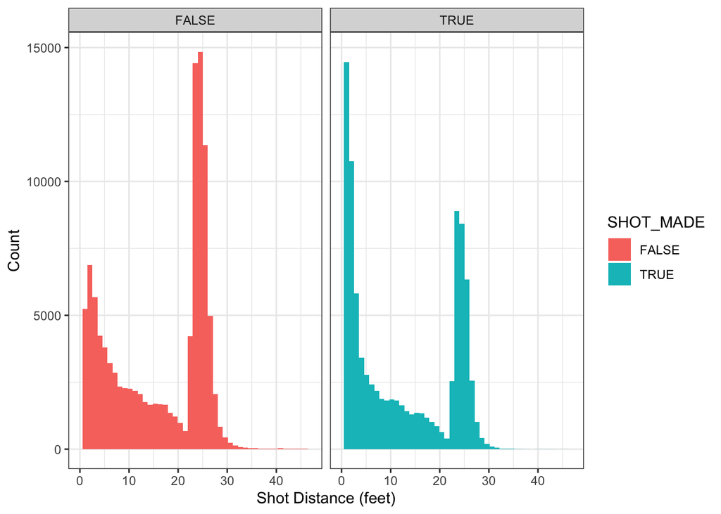

```r
ggplot(shots23) +
  geom_histogram(mapping = aes(x = SHOT_DISTANCE, fill = SHOT_MADE), bins = 47) +
  facet_wrap(~SHOT_MADE) +
  xlab("Shot Distance (feet)") +
  ylab("Count") +
  theme_bw() +
  xlim(0,47)
```

From the histograms above, there seems to be a trend to the distances with which shots are taken. Most attempts (make or miss) occur either within 5 feet or between around 22 to 27 feet. These distances represent layups/dunks and 3 point attempts. However, we can see that layups/dunks seem to be made more often than missed, whereas 3 point attempts are missed more often than made.

```r
# t-test for comparison of means
t.test(SHOT_DISTANCE ~ SHOT_MADE, data=shots23)
```

```
##
##  Welch Two Sample t-test
##
## data:  SHOT_DISTANCE by SHOT_MADE
## t = 113.56, df = 214825, p-value < 2.2e-16
## alternative hypothesis: true difference in means between group FALSE and group TRUE is not equal to 0
## 95 percent confidence interval:
##  4.916074 5.088758
## sample estimates:
## mean in group FALSE  mean in group TRUE
##            15.83575            10.83333
```

From the t-test output, we can see that there is a significant difference in the average distance of a made shot versus the average distance of a missed shot. Made shots tend to be around 11 feet in distance whereas missed shots are closer to 16 feet in distance from the basket.

#### Shot Type by Position

Next, we can look at how different positions vary in the shot attempts they take. We can look at the ZONE_RANGE variable, which sections the distances of shots into 5 categories, representing short-range shots, mid-range shots, long 2 pointers/short 3 pointers, 3 point shots, and back court shots. We can remove back court shots, as those are beyond half-court and are not shots being taken in a normal offense.

```r
# remove back court shots (shots past half-court)
shots23_zones <- shots23 %>%
  filter(ZONE_RANGE != "Back Court Shot")
# create table showing the proportion of shots for each position by zone
prop.table(table(shots23_zones$POSITION, shots23_zones$ZONE_RANGE), margin = 1) %>%
  round(digits=2)
```

```
##
##         16-24 ft. 24+ ft. 8-16 ft. Less Than 8 ft.
##   C          0.04    0.18     0.13            0.65
##   PF         0.05    0.38     0.11            0.45
##   PF-SF      0.13    0.33     0.30            0.25
##   PG         0.08    0.42     0.17            0.34
##   SF         0.06    0.44     0.12            0.37
##   SF-SG      0.03    0.32     0.10            0.56
##   SG         0.07    0.46     0.13            0.34
##   SG-PG      0.07    0.49     0.16            0.27
```

The previous table indicates that shot distances tend to vary by position. For example, a majority of centers’ shot attempts are coming from less than 8 feet (65% of total shots). On the other hand, only 34% of point guards’ shot attempts are coming from less than 8 feet, and 42% of their shots are coming from 24+ feet (3 pointers). The PF-SF position appears to have the most diverse shot selection, as it is the only position with over 10% of attempts from each of the 4 distances and over 20% of attempts from 8-16 feet (mid-range).

```r
# Chi-square test for association between position and shot distance zone
chisq.test(table(shots23_zones$POSITION, shots23_zones$ZONE_RANGE))
```

```
##
##  Pearson's Chi-squared test
##
## data:  table(shots23_zones$POSITION, shots23_zones$ZONE_RANGE)
## X-squared = 13140, df = 21, p-value < 2.2e-16
```

Looking at a chi-square test, which tests for the association between categorical variables, we can see that there is strong evidence of an association between the two variables. This tells us that certain positions tend to take shots from specific distance ranges more frequently than others.

#### Distribution of Shots Using Coordinates

Using the X or Y coordinate variables, we can see how shots are distributed either width-wise or length-wise on the court. We will introduce methods for properly displaying the (x,y) coordinates together later on in the lesson. Here, let’s take a look at how shots are distributed from right to left on a basketball court.

As mentioned previously, a basketball court is 50 feet in width and 94 feet in length. In our data set, the values from -25 to 0 represent the right half of the court, while 0 to 25 represent the left half of the court. 0 represents the center of the court width-wise.

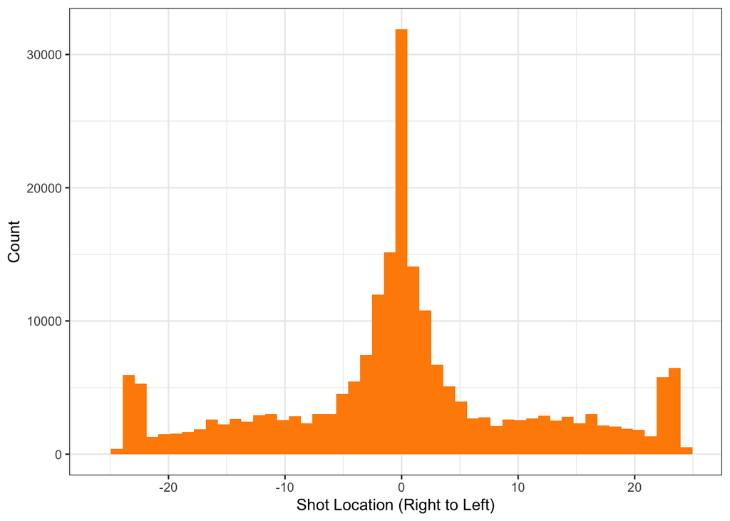

```r
ggplot(shots23) +
  geom_histogram(mapping = aes(x = LOC_X), fill = "Dark Orange", bins = 50) +
  xlab("Shot Location (Right to Left)") +
  ylab("Count") +
  theme_bw()
```

As expected, the shot distribution for players is essentially symmetrical, with a majority of the shots coming in the middle of the court and spikes towards the edges (most likely from corner 3 point attempts). If shot attempts were not spread out and occurred more in one half of the court than the other, teams would be predictable and easier to defend.

#### Activity

Before we move on to specific methods related to spatial analysis, work with your partner to explore the data further. Create at least one visualization using ggplot and write a couple sentences describing some takeaways from the visual. Additionally, compare another set of variables and find if there is a significant correlation or association between them.

## Spatial Data Visualization

As mentioned previously, the “spatial” part of our data is represented as x and y coordinates from the variables *LOC_X* and *LOC_Y*, which are both measured in feet*.* Once again, a basketball court is **50 feet in width by 94 feet in length.**

*LOC_X* ranges from -25 (right sideline) to 25 (left sideline). 0 would be the middle section of the court.

*LOC_Y* ranges from 0 (baseline) to 87.25 (endline). 47 would represent a shot from half-court.

### Visuals

A major benefit of working with spatial analysis are the many visualization methods available to us. We will cover some of the more popular techniques here, and I will provide some resources later on in the file if you wish to explore spatial visualizations further on your own time.

#### Spray Charts (Shot Charts)

A spray chart is one of the most basic ways to visualize data in sports. This is commonly used in both baseball and basketball to visualize the outcomes of events such as hits, shots, or passes.

Let’s say we want to make a spray chart for the shots attempted by the NBA champion Denver Nuggets during the 2022-2023 season.

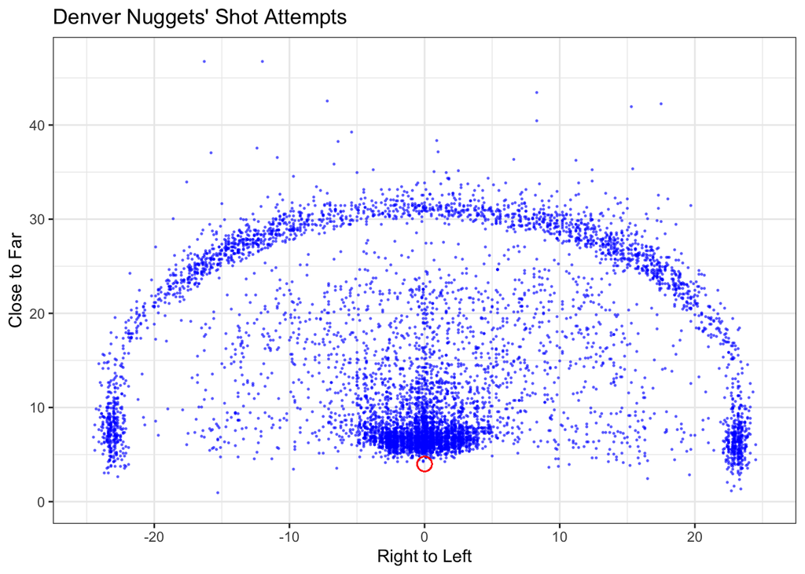

```r
DEN <- shots23 %>% filter(TEAM_NAME == "Denver Nuggets")

ggplot(data = DEN) +
  geom_point(data = DEN, aes(x = LOC_X, y = LOC_Y), alpha = 0.5, size = 0.25, color = "blue") +
  geom_point(x = 0, y = 4, color = "red", size = 4, shape = 1, fill = "transparent") +
  xlab("Right to Left") +
  ylab("Close to Far") +
  ggtitle("Denver Nuggets' Shot Attempts") +
  xlim(-25, 25) +
  ylim(0, 47) +
  theme_bw()
```

As we can see from the chart above, a spray chart in basketball can show us the occurrences of events (in this case, each event is a shot attempt). We can improve our visuals with the *shotchart()* function, which can be found in the **BasketballAnalyzeR** package, to improve our spray charts. This package allows us to visualize shots in different ways on a graph that includes the lines of a basketball court. There are many packages and functions that can accomplish similar things for basketball and other sports as well.

Let’s take a look at Finals MVP Nikola Jokic’s shot attempts for the 2022-2023 season. Often, analysis using shot attempts may want to look at makes versus misses.

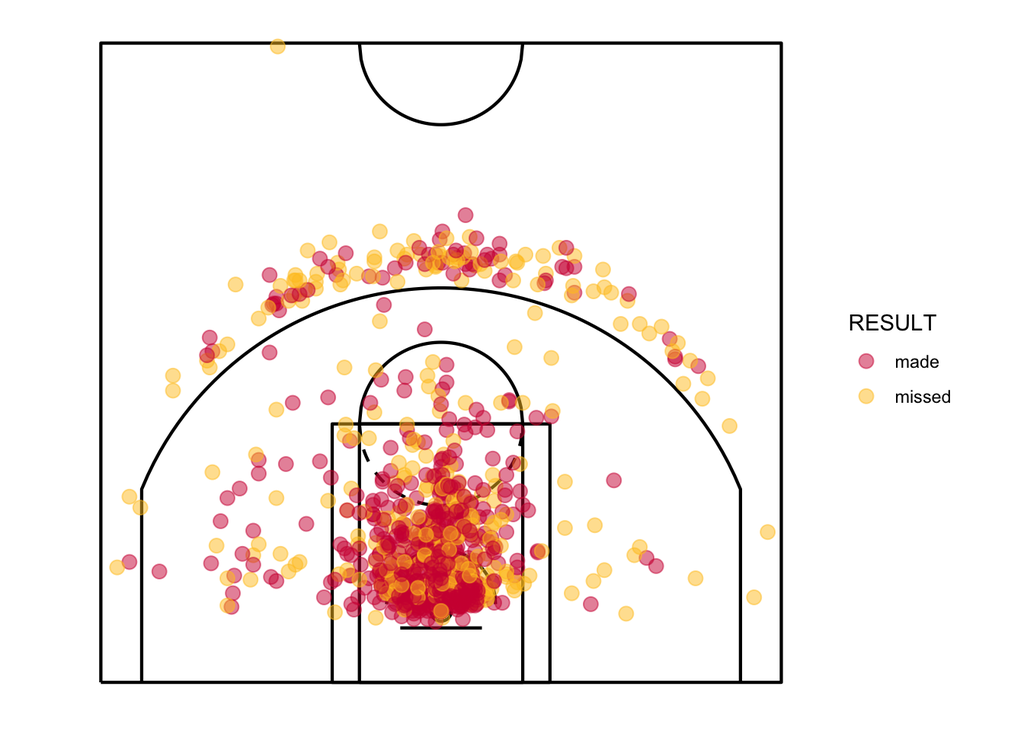

```r
# have to first change the Y coordinate, as the center of the court is set at (0,0)
JOK <- shots23 %>% filter(PLAYER_NAME == "Nikola Jokic")
JOK$XX <- JOK$LOC_X
JOK$YY <- JOK$LOC_Y-47
JOK$RESULT <- ifelse(JOK$SHOT_MADE == TRUE, "made", "missed") # create new variable for shot result
JOK$RESULT <- as.factor(JOK$RESULT) # turn result variable into factor variable
shotchart(data = JOK, x = 'XX', y = 'YY', z = "RESULT", pt.alpha = .5, palette = "hot", scatter = T)
```

This chart above shows us the shot attempts that Nikola Jokic made and missed throughout the season. It appears that he is an especially accurate shooter from the right side of the court (right of the basket, not right side of plot), especially in the mid-range area. We also see that his shot selection is fairly diverse as opposed to most centers in the NBA, as he is able to shoot from many distances on the court. However, it seems like he may struggle from the left side which could be the reason behind why there are not many attempts from that side.

#### Heatmaps

Another way of visualizing spatial data could be to look at the density of values. Plots which use color intensity to reflect the density in certain areas are often referred to as *heatmaps*. In our data, we can see the density of Nikola Jokic’s shot attempts by location on the basketball court.

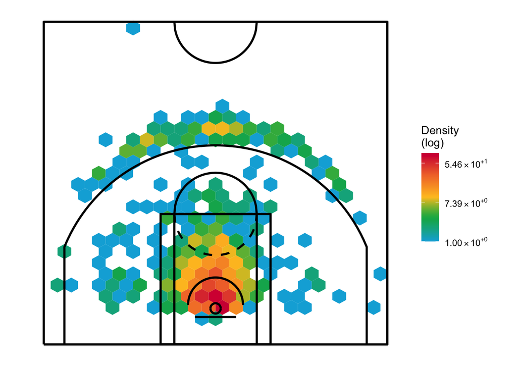

```r
shotchart(data = JOK, x = "XX", y = "YY", type = "density-hexbin", nbins = 25, legend = T)
```

In this hexagonal heatmap, we can see that the red hexagons have the most density, indicating the most shot attempts from that area, whereas the light blue hexagons indicate the least density or least shot attempts from that area. As expected, Nikola Jokic tends to take the most attempts near the basket. This plot shows that Jokic also frequently takes top-of-the-key 3 point attempts, which are the yeellow hexagons in the center of the x-axis above the three point line.

#### Choropleth Maps

Choropleth maps are versions of shot charts which are used in many sports (Basketball, Soccer, Hockey, etc.). Choropleth maps divide the playing field into regions with a common goal of visualizing spatial patterns such as number of attempts or player/team efficiency.

Using a choropleth map, we can look at how efficient Nikola Jokic is by each area of the court.

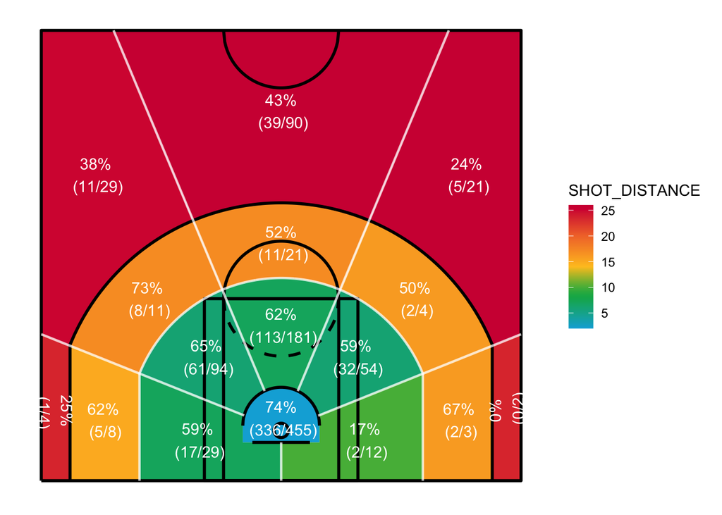

```r
shotchart(data = JOK, x = "XX", y = "YY", num.sect = 5, type = "sectors", z = "SHOT_DISTANCE", result = "RESULT", palette = "mixed")
```

We see that Jokic is the most successful closest to the basket, shooting 74% with 455 attempts. He finds similar success around the right wing area just under the three point line, shooting 73% but only on 11 attempts. He is very effective in the areas just around the basket except for the close left side. He is only shooting 17% on 12 attempts whereas in the other four sections around the basket, he is shooting at least 59% with high volume.

### Advanced Visualization Methods

We have covered some of the more common and fundamental visualization methods associated with spatial analysis in sports data, but there are plenty of other advanced methods that could be used as well, including:

- Trajectory Plots
- Voronoi Diagrams
- Spatial Interpolation Plot
- Player Tracking Visualizations
- Passing Networks

To introduce one of these advanced methods, we will look at how to create a Voronoi Diagram.

#### Voronoi Diagram

This diagram is named after Russian mathematician Georgy Voronoi, who defined the general n-dimensional case in 1908.

A Voronoi Diagram is made by plotting points on a Euclidean plane. This plane is then divided and covered by tessellating polygons. This means that the polygons cover the entire plane without any overlaps or gaps. These polygons can also be referred to as cells. There is one polygon around each point, and it takes up the area of the plane closer to that point than any other point. Voronoi tessellations are created by radial outward growth from the points.

Here are a few examples in different dimensions:

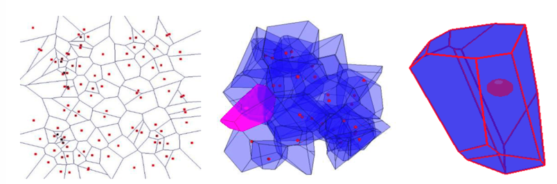

This is an interesting article about Voronoi Diagrams with some more examples: https://www.kdnuggets.com/2022/11/quick-overview-voronoi-diagrams.html

With our data, we can use Voronoi Diagrams to see how different players have different shooting tendencies or preferences in regards to their position on the court.

Let’s take a look at LeBron James vs. Kevin Durant.

First, let’s cluster their shot attempts so that there are not too many points or polygons . We can use a k-means clustering technique to do this. Too many polygons would make the diagram very cluttered and hard to read/understand.

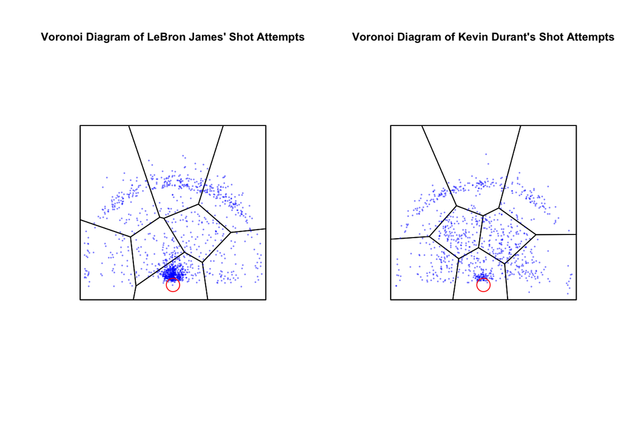

```r
# Filter data set for the players' shooting data
LBJ <- shots23 %>% filter(PLAYER_NAME == "LeBron James")
KD <- shots23 %>% filter(PLAYER_NAME == "Kevin Durant")

# Perform k-means clustering with 8 clusters (# of clusters could be anything)
kLBJ <- kmeans(cbind(LBJ$LOC_X, LBJ$LOC_Y), centers = 8)
kKD <- kmeans(cbind(KD$LOC_X, KD$LOC_Y), centers = 8)
LBJ$cluster <- kLBJ$cluster
KD$cluster <- kKD$cluster

# Find Centers
cLBJ <- data.frame(cbind(kLBJ$centers[,1], kLBJ$centers[,2]))
cKD <-data.frame(cbind(kKD$centers[,1], kKD$centers[,2]))

# Create Voronoi Diagram using spatstat package
LBJppp <- ppp(x = cLBJ$X1, y = cLBJ$X2, xrange = c(-25, 25), yrange = c(0, 47))
KDppp <- ppp(x = cKD$X1, y = cKD$X2, xrange = c(-25, 25), yrange = c(0, 47))

vLBJ <- dirichlet(LBJppp)
vKD <- dirichlet(KDppp)

# Overlay Voronoi diagram on scatterplot
par(mfrow = c(1,2), cex.main = .75)

plot(vLBJ, main = "Voronoi Diagram of LeBron James' Shot Attempts")
points(LBJ$LOC_X, LBJ$LOC_Y, col = rgb(0, 0, 1, alpha = .5), pch = 16, cex = .25)
points(0, 4, col = "red", pch = 1, cex = 2)

plot(vKD, main = "Voronoi Diagram of Kevin Durant's Shot Attempts")
points(KD$LOC_X, KD$LOC_Y, col = rgb(0, 0, 1, alpha = .5), pch = 16, cex = .25)
points(0, 4, col = "red", pch = 1, cex = 2)
```

#### Activity

Using one of the visualization methods we have just covered, compare two different players’ shooting ability or preference based on location. Discuss with your partner what your graphs tell you about the players and how this information could be used strategically.

## Spatial Analysis

### What is spatial analysis?

Spatial analysis, or spatial statistics, is the proceses of using analytic techniques to find and understand relationships, patterns, and processes with spatial data. This can involve exploring, visualizing, modeling, and interpreting spatially referenced data. We can be interested in both quantitative and qualitative data in spatial analysis.

Quantitative data in our example data could include shot accuracy, shot distance, or scoring efficiency (points per shot). Here are some spatial analysis methods associated with quantitative data:

- Spatial Autocorrelation
- Spatial Interpolation
- Regression Analysis
- Spatial Clustering

Qualitative data in our example data could include shot type, shot zone, action of the shot, shot outcome, position/location of the player, etc. Here are some spatial analysis methods associated with qualitative data:

- Spatial Overlay
- Spatial Join
- Spatial Pattern Analysis

### Quantitative Spatial Analysis

In this section, we will cover a couple of spatial analysis methods focusing on quantitative data.

#### Spatial Autocorrelation

To understand spatial autocorrelation, let’s first dive into what autocorrelation is. We know that correlation measures the degree to which separate variables are linearly related. **Autocorrelation** refers to the amount of correlation between values of the same variables across different observations in a data set.

This is very popular in *time series data*. An example of this could be average temperature measured at different months of the year. We would expect the average temperature of back-to-back months such as December and January to be more similar than the average temperature of months that are far apart such as December and June. The *Durbin-Watson* test is a popular method for testing this autocorrelation.

**Autocorrelation can cause problems in conventional analyses and statistical methods where independence of observations is assumed.**

**Spatial Autocorrelation** describes the degree to which observations or values at spatial locations are similar to each other.

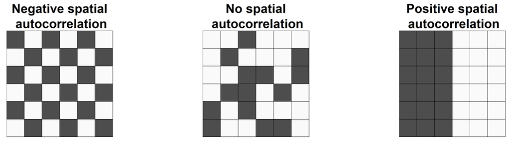

This image shows examples of spatial autocorrelation. It was found at this website: https://www.paulamoraga.com/book-spatial/spatial-autocorrelation.html which can tell you more about spatial autocorrelation and other methods of spatial statistics. Much of the information here will come from that link.

The most popular method for testing for spatial autocorrelation is **Moran’s I**.

*Moran’s I* measures spatial autocorrelation by finding the degree of similarity between neighboring observations or regions. This degree of similarity ranges from -1 to 1, with -1 being fully dispersed and 1 being fully clustered. Fully dispersed means that observations with dissimilar values are closer together and fully clustered means that observations with similar values are closer together.

**Important Formulas**

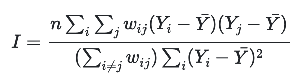

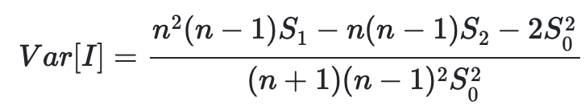

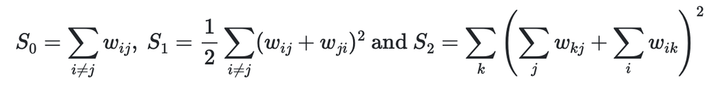

- n represents the number of regions, Y<sub>i</sub> represents the observed value of the variable of interest in region i, $\bar{Y}$ is the mean of all values, and w<sub>ij</sub> are spatial weights that denote the spatial proximity between regions i and j

- Moran’s I values significantly **above** E[I] indicate positive spatial autocorrelation
- Moran’s I values significantly **below** E[I] indicate negative spatial autocorrelation
- Moran’s I **around** E[I] indicate randomness

Below, we can calculate Moran’s I using code.

```r
# Step 2: Define spatial weights
# Example using k-nearest neighbors (adjust k as needed)
coords <- cbind(LBJ$LOC_X, LBJ$LOC_Y)
# Assuming your data is in a projected coordinate system
nb <- knn2nb(knearneigh(coords, k = 8))
W <- nb2listw(nb, style = "W")

# Step 3: Calculate Moran's I for shot outcome
# Assuming 'shot_outcome' is a binary variable (0 for miss, 1 for made)
moransI <- moran.test(as.numeric(LBJ$SHOT_MADE), listw = W)
print(moransI)
```

```
##
##  Moran I test under randomisation
##
## data:  as.numeric(LBJ$SHOT_MADE)
## weights: W
##
## Moran I statistic standard deviate = 13.378, p-value < 2.2e-16
## alternative hypothesis: greater
## sample estimates:
## Moran I statistic       Expectation          Variance
##      0.1786289671     -0.0008210181      0.0001799318
```

From the output above, we see that the p-value is extremely small, giving us strong evidence against the null hypothesis and evidence of positive spatial autocorrelation. This tells us that there is a non-random spatial pattern in the shot success for LeBron James. He will tend to be more successful from certain areas of the court as opposed to other areas. This is an expected outcome, as he is more efficient closer to the basket.

#### Spatial Regression Analysis

This is very similar to traditional regression models and methods, however, spatial regression analysis is used to account for spatial autocorrelation, spatial heterogeneity, and other spatial structures which could be present in data.

Spatial regression analysis can be used to capture spatial relationships, offer an improved model fit compared to traditional methods, and provide insights into important variables that can be used to predict outcomes for specific spatial regions or areas.

**Spatial Lag Model** (This information can be found at https://lost-stats.github.io/Geo-Spatial/spatial_lag_model.html)

To account for spatial autocorrelation, we can use a *Spatial Lag Model*, in which

a dependent variable is predicted using the value of the dependent variable’s neighbors.

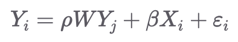

- Y<sub>j</sub> denotes the set of Y values from observations other than Y<sub>i</sub>
- W is a matrix of spatial weights which are larger for observations j closer to i

There are methods for finding the neighbors for each observation, such as *K-nearest neighbors*.

Let’s look again at the **LBJ** data set, which we saw from the previous section had strong evidence of spatial autocorrelation regarding shot success. We will run a spatial lag model predicting the shot outcome from the shot zone and the shot distance.

```r
# We can use same code as before to get the nearest neighbors and define the spatial weights
coords <- cbind(LBJ$LOC_X, LBJ$LOC_Y)
nb <- knn2nb(knearneigh(coords, k = 10))
W <- nb2listw(nb, style = "W")

# Spatial regression model
srm <- lagsarlm(as.numeric(SHOT_MADE) ~ ZONE_NAME + SHOT_DISTANCE, data = LBJ, listw = W)
summary(srm)
```

```
##
## Call:lagsarlm(formula = as.numeric(SHOT_MADE) ~ ZONE_NAME + SHOT_DISTANCE,
##     data = LBJ, listw = W)
##
## Residuals:
##      Min       1Q   Median       3Q      Max
## -0.77968 -0.37613 -0.13577  0.35068  0.85352
##
## Type: lag
## Coefficients: (asymptotic standard errors)
##                              Estimate Std. Error z value  Pr(>|z|)
## (Intercept)                 0.5445494  0.0458166 11.8854 < 2.2e-16
## ZONE_NAMELeft Side         -0.1380073  0.0548554 -2.5158   0.01187
## ZONE_NAMELeft Side Center   0.0271063  0.0490464  0.5527   0.58049
## ZONE_NAMERight Side        -0.0761280  0.0597195 -1.2748   0.20239
## ZONE_NAMERight Side Center  0.0546544  0.0541163  1.0099   0.31252
## SHOT_DISTANCE              -0.0127952  0.0019094 -6.7013 2.066e-11
##
## Rho: 0.23513, LR test value: 16.09, p-value: 6.0395e-05
## Asymptotic standard error: 0.057554
##     z-value: 4.0854, p-value: 4.4001e-05
## Wald statistic: 16.691, p-value: 4.4001e-05
##
## Log likelihood: -794.0217 for lag model
## ML residual variance (sigma squared): 0.2144, (sigma: 0.46303)
## Number of observations: 1219
## Number of parameters estimated: 8
## AIC: 1604, (AIC for lm: 1618.1)
## LM test for residual autocorrelation
## test value: 0.11078, p-value: 0.73926
```

Two important results to note:

1. The LR test p-value of 6.0395e-05 indicates that there is significant spatial autocorrelation in the model.
2. The LM test p-value of .74 indicates that there is no strong evidence of residual spatial autocorrelation, meaning our spatial lag model captures the spatial autocorrelation in the data.

```r
# compare spatial lag model to normal linear model
normal <- lm(as.numeric(SHOT_MADE) ~ ZONE_NAME + SHOT_DISTANCE, data = LBJ)
anova(srm,normal)
```

```
##        Model df    AIC  logLik Test L.Ratio    p-value
## srm        1  8 1604.0 -794.02    1
## normal     2  7 1618.1 -802.07    2   16.09 6.0395e-05
```

From the output above, we can see that the anova test comparing the two models results in an extremely small p-value. This tells us that the spatial lag model fits the data much better than a normal linear model.

  ```r
  # exponentiate Left Zone estimate
  exp(-.138)
  ```

  ```
  ## [1] 0.8710987
  ```

#### Activity

  Discuss with your partner how you would interpret the estimate for the *SHOT_DISTANCE* variable. Using this knowledge along with the output from the spatial lag model, talk about what this tells us about LeBron’s shooting ability, and how can teams use this to their advantage?

## Conclusion

In this lesson, we have introduced spatial data in the context of basketball shots. We have covered what spatial data is, how it appears, and how it can be used. There are many visualization techniques associated with spatial data, and we covered a few of them including spray charts, heat maps, choropleth maps, and voronoi diagrams. In terms of spatial analysis, it is extremely important to consider spatial autocorrelation when working with spatial data. When spatial autocorrelation is prevalent, we need to adjust for it, as normal methods of modeling data will not be sufficient. This was shown in our implementation of the spatial lag model. This lesson only scratches the surface of the possible uses and techniques related to spatial data. I encourage you to check out some of the links listed below in the “Additional Resources” section, to see how spatial data can be visualized and analyzed.

## Additional Resources

https://www.tandfonline.com/doi/full/10.1080/10691898.2020.1844104

This article explains what spatial data is and gives examples on how it could be used. The examples are non-sports related. There is also extra resources including R code that is listed.

https://www.geographyrealm.com/game-analysis-gis-football-soccer/

This is a short article which explains how spatial data is used in soccer and what implications the analysis can have. There are some links at the bottom to in-depth, peer-reviewed articles about analysis with soccer data.

https://grantland.com/features/kirk-goldsberry-introduces-new-way-understand-nba-best-scorers/

This article relates to this lesson plan, as it dives into assessing basketball players based on shots from different locations. The author offers insight into what the data can and can’t tell us about different players.

https://www.sportperformanceanalysis.com/article/how-the-nfl-developed-expected-rushing-yards-with-the-big-data-bowl

This article details approaches to spatial data used in the NFL’s Big Data Bowl. The spatial data was used to assess “yards over expectation” which is a popular metric now used in the NFL.

http://www.lukebornn.com/papers/cervone_ssac_2016.pdf

This article from the MIT Sloan Sports Analytics Conference shows how spatial data in basketball and Voronoi diagrams can be used to give insights into valuable areas of the court and the effectiveness of defenders.

https://pages.cms.hu-berlin.de/EOL/gcg_quantitative-methods/Lab15_SpatialRegression.html#Spatial_lag_model

This online textbook further explains Moran’s I test, spatial weights, spatial lag models, etc.